# Risk Factor Analysis

## Outcome Variable

**Outcome Variable:** ever_wasted

## Predictor Variables

**Intervention Variable:** impfloor

**Adjustment Set:**

- arm
- sex
- W_mage
- meducyrs
- feducyrs
- hhwealth_quart
- hfoodsec
- W_mhtcm
- W_mwtkg
- W_mbmi
- W_nrooms
- W_nchldlt5
- W_parity
- impsan
- safeh20
- delta_W_mage
- delta_meducyrs
- delta_feducyrs
- delta_hhwealth_quart
- delta_hfoodsec
- delta_W_mhtcm
- delta_W_mwtkg
- delta_W_mbmi
- delta_W_nrooms
- delta_W_nchldlt5
- delta_W_parity
- delta_impsan
- delta_safeh20

## Stratifying Variables

The analysis was stratified on these variable(s):

- agecat
- studyid
- country

## Data Summary

| agecat | studyid | country | impfloor | ever_wasted | n_cell | n |
| --- | --- | --- | --- | --- | --- | --- |
| 0-24 months (no birth wast) | CMC-V-BCS-2002 | INDIA | 1 | 0 | 145 | 258 |
| 0-24 months (no birth wast) | CMC-V-BCS-2002 | INDIA | 1 | 1 | 113 | 258 |
| 0-24 months (no birth wast) | CMC-V-BCS-2002 | INDIA | 0 | 0 | 0 | 258 |
| 0-24 months (no birth wast) | CMC-V-BCS-2002 | INDIA | 0 | 1 | 0 | 258 |
| 0-24 months (no birth wast) | CONTENT | PERU | 1 | 0 | 197 | 215 |
| 0-24 months (no birth wast) | CONTENT | PERU | 1 | 1 | 4 | 215 |
| 0-24 months (no birth wast) | CONTENT | PERU | 0 | 0 | 14 | 215 |
| 0-24 months (no birth wast) | CONTENT | PERU | 0 | 1 | 0 | 215 |
| 0-24 months (no birth wast) | GMS-Nepal | NEPAL | 1 | 0 | 47 | 518 |
| 0-24 months (no birth wast) | GMS-Nepal | NEPAL | 1 | 1 | 46 | 518 |
| 0-24 months (no birth wast) | GMS-Nepal | NEPAL | 0 | 0 | 211 | 518 |
| 0-24 months (no birth wast) | GMS-Nepal | NEPAL | 0 | 1 | 214 | 518 |
| 0-24 months (no birth wast) | IRC | INDIA | 1 | 0 | 135 | 305 |
| 0-24 months (no birth wast) | IRC | INDIA | 1 | 1 | 170 | 305 |
| 0-24 months (no birth wast) | IRC | INDIA | 0 | 0 | 0 | 305 |
| 0-24 months (no birth wast) | IRC | INDIA | 0 | 1 | 0 | 305 |
| 0-24 months (no birth wast) | JiVitA-3 | BANGLADESH | 1 | 0 | 1773 | 26465 |
| 0-24 months (no birth wast) | JiVitA-3 | BANGLADESH | 1 | 1 | 314 | 26465 |
| 0-24 months (no birth wast) | JiVitA-3 | BANGLADESH | 0 | 0 | 20212 | 26465 |
| 0-24 months (no birth wast) | JiVitA-3 | BANGLADESH | 0 | 1 | 4166 | 26465 |
| 0-24 months (no birth wast) | JiVitA-4 | BANGLADESH | 1 | 0 | 525 | 5380 |
| 0-24 months (no birth wast) | JiVitA-4 | BANGLADESH | 1 | 1 | 122 | 5380 |
| 0-24 months (no birth wast) | JiVitA-4 | BANGLADESH | 0 | 0 | 3468 | 5380 |
| 0-24 months (no birth wast) | JiVitA-4 | BANGLADESH | 0 | 1 | 1265 | 5380 |
| 0-24 months (no birth wast) | MAL-ED | BANGLADESH | 1 | 0 | 173 | 242 |
| 0-24 months (no birth wast) | MAL-ED | BANGLADESH | 1 | 1 | 50 | 242 |
| 0-24 months (no birth wast) | MAL-ED | BANGLADESH | 0 | 0 | 12 | 242 |
| 0-24 months (no birth wast) | MAL-ED | BANGLADESH | 0 | 1 | 7 | 242 |
| 0-24 months (no birth wast) | MAL-ED | BRAZIL | 1 | 0 | 195 | 210 |
| 0-24 months (no birth wast) | MAL-ED | BRAZIL | 1 | 1 | 13 | 210 |

[output cut: 162 more lines]

The following strata were considered:

- agecat: 0-24 months (no birth wast), studyid: CMC-V-BCS-2002, country: INDIA
- agecat: 0-24 months (no birth wast), studyid: CONTENT, country: PERU
- agecat: 0-24 months (no birth wast), studyid: GMS-Nepal, country: NEPAL
- agecat: 0-24 months (no birth wast), studyid: IRC, country: INDIA
- agecat: 0-24 months (no birth wast), studyid: JiVitA-3, country: BANGLADESH
- agecat: 0-24 months (no birth wast), studyid: JiVitA-4, country: BANGLADESH
- agecat: 0-24 months (no birth wast), studyid: MAL-ED, country: BANGLADESH
- agecat: 0-24 months (no birth wast), studyid: MAL-ED, country: BRAZIL
- agecat: 0-24 months (no birth wast), studyid: MAL-ED, country: INDIA
- agecat: 0-24 months (no birth wast), studyid: MAL-ED, country: NEPAL
- agecat: 0-24 months (no birth wast), studyid: MAL-ED, country: PERU
- agecat: 0-24 months (no birth wast), studyid: MAL-ED, country: SOUTH AFRICA
- agecat: 0-24 months (no birth wast), studyid: MAL-ED, country: TANZANIA, UNITED REPUBLIC OF
- agecat: 0-24 months (no birth wast), studyid: NIH-Birth, country: BANGLADESH
- agecat: 0-24 months (no birth wast), studyid: NIH-Crypto, country: BANGLADESH
- agecat: 0-24 months (no birth wast), studyid: PROVIDE, country: BANGLADESH
- agecat: 0-6 months (no birth wast), studyid: CMC-V-BCS-2002, country: INDIA
- agecat: 0-6 months (no birth wast), studyid: CONTENT, country: PERU
- agecat: 0-6 months (no birth wast), studyid: GMS-Nepal, country: NEPAL
- agecat: 0-6 months (no birth wast), studyid: IRC, country: INDIA
- agecat: 0-6 months (no birth wast), studyid: JiVitA-3, country: BANGLADESH
- agecat: 0-6 months (no birth wast), studyid: JiVitA-4, country: BANGLADESH
- agecat: 0-6 months (no birth wast), studyid: MAL-ED, country: BANGLADESH
- agecat: 0-6 months (no birth wast), studyid: MAL-ED, country: BRAZIL
- agecat: 0-6 months (no birth wast), studyid: MAL-ED, country: INDIA
- agecat: 0-6 months (no birth wast), studyid: MAL-ED, country: NEPAL
- agecat: 0-6 months (no birth wast), studyid: MAL-ED, country: PERU
- agecat: 0-6 months (no birth wast), studyid: MAL-ED, country: SOUTH AFRICA
- agecat: 0-6 months (no birth wast), studyid: MAL-ED, country: TANZANIA, UNITED REPUBLIC OF
- agecat: 0-6 months (no birth wast), studyid: NIH-Birth, country: BANGLADESH
- agecat: 0-6 months (no birth wast), studyid: NIH-Crypto, country: BANGLADESH
- agecat: 0-6 months (no birth wast), studyid: PROVIDE, country: BANGLADESH
- agecat: 6-24 months, studyid: CMC-V-BCS-2002, country: INDIA
- agecat: 6-24 months, studyid: CONTENT, country: PERU
- agecat: 6-24 months, studyid: GMS-Nepal, country: NEPAL
- agecat: 6-24 months, studyid: IRC, country: INDIA
- agecat: 6-24 months, studyid: JiVitA-3, country: BANGLADESH
- agecat: 6-24 months, studyid: JiVitA-4, country: BANGLADESH
- agecat: 6-24 months, studyid: MAL-ED, country: BANGLADESH
- agecat: 6-24 months, studyid: MAL-ED, country: BRAZIL
- agecat: 6-24 months, studyid: MAL-ED, country: INDIA
- agecat: 6-24 months, studyid: MAL-ED, country: NEPAL
- agecat: 6-24 months, studyid: MAL-ED, country: PERU
- agecat: 6-24 months, studyid: MAL-ED, country: SOUTH AFRICA
- agecat: 6-24 months, studyid: MAL-ED, country: TANZANIA, UNITED REPUBLIC OF
- agecat: 6-24 months, studyid: NIH-Birth, country: BANGLADESH
- agecat: 6-24 months, studyid: NIH-Crypto, country: BANGLADESH
- agecat: 6-24 months, studyid: PROVIDE, country: BANGLADESH

### Dropped Strata

- agecat: 0-24 months (no birth wast), studyid: CMC-V-BCS-2002, country: INDIA
- agecat: 0-24 months (no birth wast), studyid: CONTENT, country: PERU
- agecat: 0-24 months (no birth wast), studyid: IRC, country: INDIA
- agecat: 0-24 months (no birth wast), studyid: MAL-ED, country: BRAZIL
- agecat: 0-24 months (no birth wast), studyid: MAL-ED, country: PERU
- agecat: 0-24 months (no birth wast), studyid: MAL-ED, country: SOUTH AFRICA
- agecat: 0-24 months (no birth wast), studyid: MAL-ED, country: TANZANIA, UNITED REPUBLIC OF
- agecat: 0-6 months (no birth wast), studyid: CMC-V-BCS-2002, country: INDIA
- agecat: 0-6 months (no birth wast), studyid: CONTENT, country: PERU
- agecat: 0-6 months (no birth wast), studyid: IRC, country: INDIA
- agecat: 0-6 months (no birth wast), studyid: MAL-ED, country: BANGLADESH
- agecat: 0-6 months (no birth wast), studyid: MAL-ED, country: BRAZIL
- agecat: 0-6 months (no birth wast), studyid: MAL-ED, country: INDIA
- agecat: 0-6 months (no birth wast), studyid: MAL-ED, country: PERU
- agecat: 0-6 months (no birth wast), studyid: MAL-ED, country: SOUTH AFRICA
- agecat: 0-6 months (no birth wast), studyid: MAL-ED, country: TANZANIA, UNITED REPUBLIC OF
- agecat: 6-24 months, studyid: CMC-V-BCS-2002, country: INDIA
- agecat: 6-24 months, studyid: CONTENT, country: PERU
- agecat: 6-24 months, studyid: IRC, country: INDIA
- agecat: 6-24 months, studyid: MAL-ED, country: BRAZIL
- agecat: 6-24 months, studyid: MAL-ED, country: PERU
- agecat: 6-24 months, studyid: MAL-ED, country: SOUTH AFRICA
- agecat: 6-24 months, studyid: MAL-ED, country: TANZANIA, UNITED REPUBLIC OF

## Methods Detail

We’re interested in the causal parameters $E[Y_a]$ for all values of $a \in \mathcal{A}$. These parameters represent the mean outcome if, possibly contrary to fact, we intervened to set all units to have $A=a$. Under the randomization and positivity assumptions, these are identified by the statistical parameters $\psi_a=E_W[E_{Y|A,W}(Y|A=a,W)]$. In addition, we’re interested in the mean of $Y$, $E[Y]$ under no intervention (the observed mean). We will estimate these parameters by using SuperLearner to fit the relevant likelihood factors – $E_{Y|A,W}(Y|A=a,W)$ and $p(A=a|W)$, and then updating our likelihood fit using a joint TMLE.

For unadjusted analyses ($W=\{\}$), initial likelihoods were estimated using Lrnr_glm to estimate the simple $E(Y|A)$ and Lrnr_mean to estimate $p(A)$. For adjusted analyses, a small library containing Lrnr_glmnet, Lrnr_xgboost, and Lrnr_mean was used.

Having estimated these parameters, we will then use the delta method to estimate relative risks and attributable risks relative to a prespecified baseline level of $A$.

# Results Detail

## Results Plots

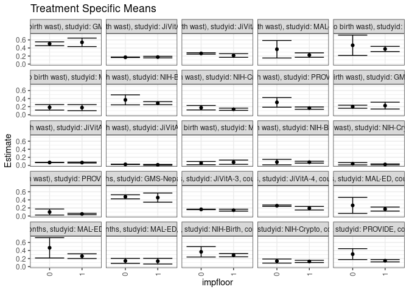

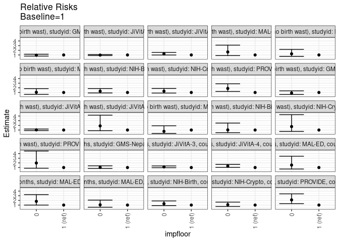

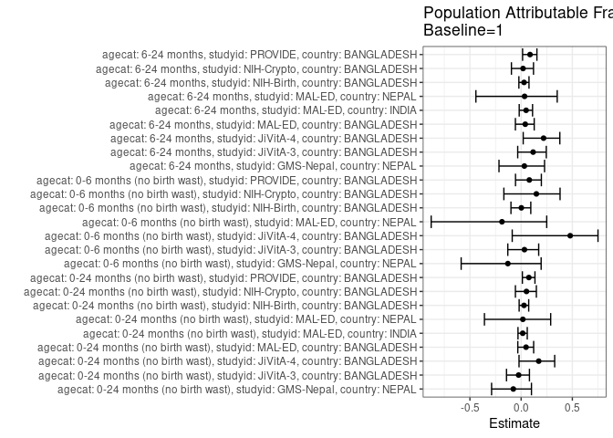

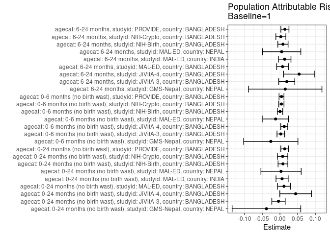

## Results Table

### Parameter: TSM

| agecat | studyid | country | intervention_level | baseline_level | estimate | ci_lower | ci_upper |
| --- | --- | --- | --- | --- | --- | --- | --- |
| 0-24 months (no birth wast) | GMS-Nepal | NEPAL | 1 | NA | 0.5402170 | 0.4348992 | 0.6455348 |
| 0-24 months (no birth wast) | GMS-Nepal | NEPAL | 0 | NA | 0.5043193 | 0.4562518 | 0.5523867 |
| 0-24 months (no birth wast) | JiVitA-3 | BANGLADESH | 1 | NA | 0.1734554 | 0.1542229 | 0.1926880 |
| 0-24 months (no birth wast) | JiVitA-3 | BANGLADESH | 0 | NA | 0.1691078 | 0.1634603 | 0.1747553 |
| 0-24 months (no birth wast) | JiVitA-4 | BANGLADESH | 1 | NA | 0.2135568 | 0.1682393 | 0.2588743 |
| 0-24 months (no birth wast) | JiVitA-4 | BANGLADESH | 0 | NA | 0.2643714 | 0.2470427 | 0.2817001 |
| 0-24 months (no birth wast) | MAL-ED | BANGLADESH | 1 | NA | 0.2242152 | 0.1693625 | 0.2790679 |
| 0-24 months (no birth wast) | MAL-ED | BANGLADESH | 0 | NA | 0.3684211 | 0.1510726 | 0.5857695 |
| 0-24 months (no birth wast) | MAL-ED | INDIA | 1 | NA | 0.3750000 | 0.3102978 | 0.4397022 |
| 0-24 months (no birth wast) | MAL-ED | INDIA | 0 | NA | 0.4666667 | 0.2136511 | 0.7196823 |
| 0-24 months (no birth wast) | MAL-ED | NEPAL | 1 | NA | 0.1760068 | 0.1011553 | 0.2508582 |
| 0-24 months (no birth wast) | MAL-ED | NEPAL | 0 | NA | 0.1834406 | 0.1151279 | 0.2517533 |
| 0-24 months (no birth wast) | NIH-Birth | BANGLADESH | 1 | NA | 0.2871079 | 0.2486142 | 0.3256015 |
| 0-24 months (no birth wast) | NIH-Birth | BANGLADESH | 0 | NA | 0.3689550 | 0.2447179 | 0.4931922 |
| 0-24 months (no birth wast) | NIH-Crypto | BANGLADESH | 1 | NA | 0.1357900 | 0.1078446 | 0.1637353 |
| 0-24 months (no birth wast) | NIH-Crypto | BANGLADESH | 0 | NA | 0.1739391 | 0.1193748 | 0.2285034 |
| 0-24 months (no birth wast) | PROVIDE | BANGLADESH | 1 | NA | 0.1641659 | 0.1351096 | 0.1932222 |
| 0-24 months (no birth wast) | PROVIDE | BANGLADESH | 0 | NA | 0.3064899 | 0.1867396 | 0.4262402 |
| 0-6 months (no birth wast) | GMS-Nepal | NEPAL | 1 | NA | 0.2263388 | 0.1416059 | 0.3110717 |
| 0-6 months (no birth wast) | GMS-Nepal | NEPAL | 0 | NA | 0.1986929 | 0.1602518 | 0.2371339 |
| 0-6 months (no birth wast) | JiVitA-3 | BANGLADESH | 1 | NA | 0.0693998 | 0.0585762 | 0.0802234 |
| 0-6 months (no birth wast) | JiVitA-3 | BANGLADESH | 0 | NA | 0.0715264 | 0.0676157 | 0.0754371 |
| 0-6 months (no birth wast) | JiVitA-4 | BANGLADESH | 1 | NA | 0.0131668 | 0.0030145 | 0.0233191 |
| 0-6 months (no birth wast) | JiVitA-4 | BANGLADESH | 0 | NA | 0.0247942 | 0.0198483 | 0.0297400 |
| 0-6 months (no birth wast) | MAL-ED | NEPAL | 1 | NA | 0.0784314 | 0.0261418 | 0.1307210 |
| 0-6 months (no birth wast) | MAL-ED | NEPAL | 0 | NA | 0.0560000 | 0.0156046 | 0.0963954 |
| 0-6 months (no birth wast) | NIH-Birth | BANGLADESH | 1 | NA | 0.0789981 | 0.0557719 | 0.1022242 |
| 0-6 months (no birth wast) | NIH-Birth | BANGLADESH | 0 | NA | 0.0806452 | 0.0128097 | 0.1484807 |
| 0-6 months (no birth wast) | NIH-Crypto | BANGLADESH | 1 | NA | 0.0227273 | 0.0105059 | 0.0349487 |
| 0-6 months (no birth wast) | NIH-Crypto | BANGLADESH | 0 | NA | 0.0395480 | 0.0108170 | 0.0682791 |
| 0-6 months (no birth wast) | PROVIDE | BANGLADESH | 1 | NA | 0.0498392 | 0.0327251 | 0.0669534 |
| 0-6 months (no birth wast) | PROVIDE | BANGLADESH | 0 | NA | 0.0983607 | 0.0235732 | 0.1731481 |
| 6-24 months | GMS-Nepal | NEPAL | 1 | NA | 0.4560178 | 0.3425556 | 0.5694799 |
| 6-24 months | GMS-Nepal | NEPAL | 0 | NA | 0.4761956 | 0.4257398 | 0.5266514 |
| 6-24 months | JiVitA-3 | BANGLADESH | 1 | NA | 0.1445775 | 0.1211981 | 0.1679569 |
| 6-24 months | JiVitA-3 | BANGLADESH | 0 | NA | 0.1639988 | 0.1574428 | 0.1705547 |
| 6-24 months | JiVitA-4 | BANGLADESH | 1 | NA | 0.1930980 | 0.1485716 | 0.2376244 |
| 6-24 months | JiVitA-4 | BANGLADESH | 0 | NA | 0.2546486 | 0.2375949 | 0.2717022 |
| 6-24 months | MAL-ED | BANGLADESH | 1 | NA | 0.1719457 | 0.1220936 | 0.2217978 |
| 6-24 months | MAL-ED | BANGLADESH | 0 | NA | 0.2631579 | 0.0647434 | 0.4615724 |
| 6-24 months | MAL-ED | INDIA | 1 | NA | 0.2590909 | 0.2010718 | 0.3171101 |
| 6-24 months | MAL-ED | INDIA | 0 | NA | 0.4666667 | 0.2136604 | 0.7196729 |
| 6-24 months | MAL-ED | NEPAL | 1 | NA | 0.1356353 | 0.0655833 | 0.2056872 |
| 6-24 months | MAL-ED | NEPAL | 0 | NA | 0.1428509 | 0.0808071 | 0.2048946 |
| 6-24 months | NIH-Birth | BANGLADESH | 1 | NA | 0.2847270 | 0.2442576 | 0.3251965 |
| 6-24 months | NIH-Birth | BANGLADESH | 0 | NA | 0.3675773 | 0.2383092 | 0.4968454 |
| 6-24 months | NIH-Crypto | BANGLADESH | 1 | NA | 0.1290148 | 0.1010670 | 0.1569625 |
| 6-24 months | NIH-Crypto | BANGLADESH | 0 | NA | 0.1381799 | 0.0873944 | 0.1889654 |
| 6-24 months | PROVIDE | BANGLADESH | 1 | NA | 0.1469911 | 0.1177564 | 0.1762257 |
| 6-24 months | PROVIDE | BANGLADESH | 0 | NA | 0.3099962 | 0.1746583 | 0.4453341 |

### Parameter: E(Y)

| agecat | studyid | country | intervention_level | baseline_level | estimate | ci_lower | ci_upper |
| --- | --- | --- | --- | --- | --- | --- | --- |
| 0-24 months (no birth wast) | GMS-Nepal | NEPAL | NA | NA | 0.5019305 | 0.4588313 | 0.5450297 |
| 0-24 months (no birth wast) | JiVitA-3 | BANGLADESH | NA | NA | 0.1692802 | 0.1639950 | 0.1745654 |
| 0-24 months (no birth wast) | JiVitA-4 | BANGLADESH | NA | NA | 0.2578067 | 0.2441658 | 0.2714476 |
| 0-24 months (no birth wast) | MAL-ED | BANGLADESH | NA | NA | 0.2355372 | 0.1819640 | 0.2891104 |
| 0-24 months (no birth wast) | MAL-ED | INDIA | NA | NA | 0.3809524 | 0.3181926 | 0.4437122 |
| 0-24 months (no birth wast) | MAL-ED | NEPAL | NA | NA | 0.1790393 | 0.1292752 | 0.2288034 |
| 0-24 months (no birth wast) | NIH-Birth | BANGLADESH | NA | NA | 0.2954925 | 0.2589234 | 0.3320615 |
| 0-24 months (no birth wast) | NIH-Crypto | BANGLADESH | NA | NA | 0.1432361 | 0.1182149 | 0.1682572 |
| 0-24 months (no birth wast) | PROVIDE | BANGLADESH | NA | NA | 0.1775837 | 0.1489858 | 0.2061816 |
| 0-6 months (no birth wast) | GMS-Nepal | NEPAL | NA | NA | 0.2003968 | 0.1654147 | 0.2353790 |
| 0-6 months (no birth wast) | JiVitA-3 | BANGLADESH | NA | NA | 0.0717206 | 0.0680809 | 0.0753604 |
| 0-6 months (no birth wast) | JiVitA-4 | BANGLADESH | NA | NA | 0.0252781 | 0.0205710 | 0.0299851 |
| 0-6 months (no birth wast) | MAL-ED | NEPAL | NA | NA | 0.0660793 | 0.0336915 | 0.0984671 |
| 0-6 months (no birth wast) | NIH-Birth | BANGLADESH | NA | NA | 0.0791738 | 0.0571996 | 0.1011481 |
| 0-6 months (no birth wast) | NIH-Crypto | BANGLADESH | NA | NA | 0.0267023 | 0.0151493 | 0.0382553 |
| 0-6 months (no birth wast) | PROVIDE | BANGLADESH | NA | NA | 0.0541728 | 0.0371844 | 0.0711612 |
| 6-24 months | GMS-Nepal | NEPAL | NA | NA | 0.4708423 | 0.4253270 | 0.5163576 |
| 6-24 months | JiVitA-3 | BANGLADESH | NA | NA | 0.1637407 | 0.1576229 | 0.1698584 |
| 6-24 months | JiVitA-4 | BANGLADESH | NA | NA | 0.2473257 | 0.2337872 | 0.2608642 |
| 6-24 months | MAL-ED | BANGLADESH | NA | NA | 0.1791667 | 0.1305478 | 0.2277856 |
| 6-24 months | MAL-ED | INDIA | NA | NA | 0.2723404 | 0.2153029 | 0.3293779 |
| 6-24 months | MAL-ED | NEPAL | NA | NA | 0.1403509 | 0.0951649 | 0.1855368 |
| 6-24 months | NIH-Birth | BANGLADESH | NA | NA | 0.2931354 | 0.2546710 | 0.3315999 |
| 6-24 months | NIH-Crypto | BANGLADESH | NA | NA | 0.1315068 | 0.1069744 | 0.1560393 |
| 6-24 months | PROVIDE | BANGLADESH | NA | NA | 0.1609756 | 0.1319065 | 0.1900447 |

### Parameter: RR

| agecat | studyid | country | intervention_level | baseline_level | estimate | ci_lower | ci_upper |
| --- | --- | --- | --- | --- | --- | --- | --- |
| 0-24 months (no birth wast) | GMS-Nepal | NEPAL | 1 | 1 | 1.0000000 | 1.0000000 | 1.000000 |
| 0-24 months (no birth wast) | GMS-Nepal | NEPAL | 0 | 1 | 0.9335494 | 0.7511996 | 1.160164 |
| 0-24 months (no birth wast) | JiVitA-3 | BANGLADESH | 1 | 1 | 1.0000000 | 1.0000000 | 1.000000 |
| 0-24 months (no birth wast) | JiVitA-3 | BANGLADESH | 0 | 1 | 0.9749352 | 0.8690789 | 1.093685 |
| 0-24 months (no birth wast) | JiVitA-4 | BANGLADESH | 1 | 1 | 1.0000000 | 1.0000000 | 1.000000 |
| 0-24 months (no birth wast) | JiVitA-4 | BANGLADESH | 0 | 1 | 1.2379444 | 0.9914686 | 1.545693 |
| 0-24 months (no birth wast) | MAL-ED | BANGLADESH | 1 | 1 | 1.0000000 | 1.0000000 | 1.000000 |
| 0-24 months (no birth wast) | MAL-ED | BANGLADESH | 0 | 1 | 1.6431579 | 0.8675868 | 3.112044 |
| 0-24 months (no birth wast) | MAL-ED | INDIA | 1 | 1 | 1.0000000 | 1.0000000 | 1.000000 |
| 0-24 months (no birth wast) | MAL-ED | INDIA | 0 | 1 | 1.2444444 | 0.7044915 | 2.198241 |
| 0-24 months (no birth wast) | MAL-ED | NEPAL | 1 | 1 | 1.0000000 | 1.0000000 | 1.000000 |
| 0-24 months (no birth wast) | MAL-ED | NEPAL | 0 | 1 | 1.0422362 | 0.5938072 | 1.829308 |
| 0-24 months (no birth wast) | NIH-Birth | BANGLADESH | 1 | 1 | 1.0000000 | 1.0000000 | 1.000000 |
| 0-24 months (no birth wast) | NIH-Birth | BANGLADESH | 0 | 1 | 1.2850745 | 0.8946332 | 1.845915 |
| 0-24 months (no birth wast) | NIH-Crypto | BANGLADESH | 1 | 1 | 1.0000000 | 1.0000000 | 1.000000 |
| 0-24 months (no birth wast) | NIH-Crypto | BANGLADESH | 0 | 1 | 1.2809424 | 0.8798625 | 1.864852 |
| 0-24 months (no birth wast) | PROVIDE | BANGLADESH | 1 | 1 | 1.0000000 | 1.0000000 | 1.000000 |
| 0-24 months (no birth wast) | PROVIDE | BANGLADESH | 0 | 1 | 1.8669523 | 1.2161669 | 2.865981 |
| 0-6 months (no birth wast) | GMS-Nepal | NEPAL | 1 | 1 | 1.0000000 | 1.0000000 | 1.000000 |
| 0-6 months (no birth wast) | GMS-Nepal | NEPAL | 0 | 1 | 0.8778559 | 0.5756899 | 1.338622 |
| 0-6 months (no birth wast) | JiVitA-3 | BANGLADESH | 1 | 1 | 1.0000000 | 1.0000000 | 1.000000 |
| 0-6 months (no birth wast) | JiVitA-3 | BANGLADESH | 0 | 1 | 1.0306418 | 0.8748116 | 1.214230 |
| 0-6 months (no birth wast) | JiVitA-4 | BANGLADESH | 1 | 1 | 1.0000000 | 1.0000000 | 1.000000 |
| 0-6 months (no birth wast) | JiVitA-4 | BANGLADESH | 0 | 1 | 1.8830814 | 0.8461895 | 4.190546 |
| 0-6 months (no birth wast) | MAL-ED | NEPAL | 1 | 1 | 1.0000000 | 1.0000000 | 1.000000 |
| 0-6 months (no birth wast) | MAL-ED | NEPAL | 0 | 1 | 0.7140000 | 0.2673693 | 1.906711 |
| 0-6 months (no birth wast) | NIH-Birth | BANGLADESH | 1 | 1 | 1.0000000 | 1.0000000 | 1.000000 |
| 0-6 months (no birth wast) | NIH-Birth | BANGLADESH | 0 | 1 | 1.0208497 | 0.4187728 | 2.488543 |
| 0-6 months (no birth wast) | NIH-Crypto | BANGLADESH | 1 | 1 | 1.0000000 | 1.0000000 | 1.000000 |
| 0-6 months (no birth wast) | NIH-Crypto | BANGLADESH | 0 | 1 | 1.7401130 | 0.7047572 | 4.296506 |
| 0-6 months (no birth wast) | PROVIDE | BANGLADESH | 1 | 1 | 1.0000000 | 1.0000000 | 1.000000 |
| 0-6 months (no birth wast) | PROVIDE | BANGLADESH | 0 | 1 | 1.9735590 | 0.8568903 | 4.545430 |
| 6-24 months | GMS-Nepal | NEPAL | 1 | 1 | 1.0000000 | 1.0000000 | 1.000000 |
| 6-24 months | GMS-Nepal | NEPAL | 0 | 1 | 1.0442479 | 0.7967688 | 1.368595 |
| 6-24 months | JiVitA-3 | BANGLADESH | 1 | 1 | 1.0000000 | 1.0000000 | 1.000000 |
| 6-24 months | JiVitA-3 | BANGLADESH | 0 | 1 | 1.1343308 | 0.9620874 | 1.337411 |
| 6-24 months | JiVitA-4 | BANGLADESH | 1 | 1 | 1.0000000 | 1.0000000 | 1.000000 |
| 6-24 months | JiVitA-4 | BANGLADESH | 0 | 1 | 1.3187528 | 1.0375458 | 1.676176 |
| 6-24 months | MAL-ED | BANGLADESH | 1 | 1 | 1.0000000 | 1.0000000 | 1.000000 |
| 6-24 months | MAL-ED | BANGLADESH | 0 | 1 | 1.5304709 | 0.6823433 | 3.432790 |
| 6-24 months | MAL-ED | INDIA | 1 | 1 | 1.0000000 | 1.0000000 | 1.000000 |
| 6-24 months | MAL-ED | INDIA | 0 | 1 | 1.8011696 | 1.0018550 | 3.238205 |
| 6-24 months | MAL-ED | NEPAL | 1 | 1 | 1.0000000 | 1.0000000 | 1.000000 |
| 6-24 months | MAL-ED | NEPAL | 0 | 1 | 1.0531986 | 0.5361448 | 2.068895 |
| 6-24 months | NIH-Birth | BANGLADESH | 1 | 1 | 1.0000000 | 1.0000000 | 1.000000 |
| 6-24 months | NIH-Birth | BANGLADESH | 0 | 1 | 1.2909813 | 0.8842694 | 1.884757 |
| 6-24 months | NIH-Crypto | BANGLADESH | 1 | 1 | 1.0000000 | 1.0000000 | 1.000000 |
| 6-24 months | NIH-Crypto | BANGLADESH | 0 | 1 | 1.0710398 | 0.6993939 | 1.640172 |
| 6-24 months | PROVIDE | BANGLADESH | 1 | 1 | 1.0000000 | 1.0000000 | 1.000000 |
| 6-24 months | PROVIDE | BANGLADESH | 0 | 1 | 2.1089459 | 1.3050815 | 3.407950 |

### Parameter: PAR

| agecat | studyid | country | intervention_level | baseline_level | estimate | ci_lower | ci_upper |
| --- | --- | --- | --- | --- | --- | --- | --- |
| 0-24 months (no birth wast) | GMS-Nepal | NEPAL | 1 | NA | -0.0382865 | -0.1353249 | 0.0587519 |
| 0-24 months (no birth wast) | JiVitA-3 | BANGLADESH | 1 | NA | -0.0041752 | -0.0230718 | 0.0147213 |
| 0-24 months (no birth wast) | JiVitA-4 | BANGLADESH | 1 | NA | 0.0442499 | -0.0004996 | 0.0889994 |
| 0-24 months (no birth wast) | MAL-ED | BANGLADESH | 1 | NA | 0.0113219 | -0.0069463 | 0.0295901 |
| 0-24 months (no birth wast) | MAL-ED | INDIA | 1 | NA | 0.0059524 | -0.0112553 | 0.0231601 |
| 0-24 months (no birth wast) | MAL-ED | NEPAL | 1 | NA | 0.0030325 | -0.0538709 | 0.0599360 |
| 0-24 months (no birth wast) | NIH-Birth | BANGLADESH | 1 | NA | 0.0083846 | -0.0054094 | 0.0221786 |
| 0-24 months (no birth wast) | NIH-Crypto | BANGLADESH | 1 | NA | 0.0074461 | -0.0072194 | 0.0221116 |
| 0-24 months (no birth wast) | PROVIDE | BANGLADESH | 1 | NA | 0.0134178 | 0.0024076 | 0.0244280 |
| 0-6 months (no birth wast) | GMS-Nepal | NEPAL | 1 | NA | -0.0259420 | -0.1026269 | 0.0507429 |
| 0-6 months (no birth wast) | JiVitA-3 | BANGLADESH | 1 | NA | 0.0023208 | -0.0084665 | 0.0131080 |
| 0-6 months (no birth wast) | JiVitA-4 | BANGLADESH | 1 | NA | 0.0121112 | 0.0023174 | 0.0219051 |
| 0-6 months (no birth wast) | MAL-ED | NEPAL | 1 | NA | -0.0123521 | -0.0487664 | 0.0240623 |
| 0-6 months (no birth wast) | NIH-Birth | BANGLADESH | 1 | NA | 0.0001758 | -0.0074758 | 0.0078273 |
| 0-6 months (no birth wast) | NIH-Crypto | BANGLADESH | 1 | NA | 0.0039750 | -0.0034211 | 0.0113711 |
| 0-6 months (no birth wast) | PROVIDE | BANGLADESH | 1 | NA | 0.0043335 | -0.0025968 | 0.0112639 |
| 6-24 months | GMS-Nepal | NEPAL | 1 | NA | 0.0148246 | -0.0889534 | 0.1186025 |
| 6-24 months | JiVitA-3 | BANGLADESH | 1 | NA | 0.0191631 | -0.0035881 | 0.0419144 |
| 6-24 months | JiVitA-4 | BANGLADESH | 1 | NA | 0.0542277 | 0.0101365 | 0.0983189 |
| 6-24 months | MAL-ED | BANGLADESH | 1 | NA | 0.0072210 | -0.0092733 | 0.0237152 |
| 6-24 months | MAL-ED | INDIA | 1 | NA | 0.0132495 | -0.0045489 | 0.0310479 |
| 6-24 months | MAL-ED | NEPAL | 1 | NA | 0.0047156 | -0.0495313 | 0.0589626 |
| 6-24 months | NIH-Birth | BANGLADESH | 1 | NA | 0.0084084 | -0.0060780 | 0.0228948 |
| 6-24 months | NIH-Crypto | BANGLADESH | 1 | NA | 0.0024921 | -0.0116540 | 0.0166382 |
| 6-24 months | PROVIDE | BANGLADESH | 1 | NA | 0.0139845 | 0.0025560 | 0.0254131 |

### Parameter: PAF

| agecat | studyid | country | intervention_level | baseline_level | estimate | ci_lower | ci_upper |
| --- | --- | --- | --- | --- | --- | --- | --- |
| 0-24 months (no birth wast) | GMS-Nepal | NEPAL | 1 | NA | -0.0762784 | -0.2883640 | 0.1008944 |
| 0-24 months (no birth wast) | JiVitA-3 | BANGLADESH | 1 | NA | -0.0246647 | -0.1426688 | 0.0811531 |
| 0-24 months (no birth wast) | JiVitA-4 | BANGLADESH | 1 | NA | 0.1716398 | -0.0205176 | 0.3276151 |
| 0-24 months (no birth wast) | MAL-ED | BANGLADESH | 1 | NA | 0.0480686 | -0.0323921 | 0.1222585 |
| 0-24 months (no birth wast) | MAL-ED | INDIA | 1 | NA | 0.0156250 | -0.0306138 | 0.0597893 |
| 0-24 months (no birth wast) | MAL-ED | NEPAL | 1 | NA | 0.0169379 | -0.3582004 | 0.2884620 |
| 0-24 months (no birth wast) | NIH-Birth | BANGLADESH | 1 | NA | 0.0283750 | -0.0194173 | 0.0739267 |
| 0-24 months (no birth wast) | NIH-Crypto | BANGLADESH | 1 | NA | 0.0519850 | -0.0557537 | 0.1487290 |
| 0-24 months (no birth wast) | PROVIDE | BANGLADESH | 1 | NA | 0.0755576 | 0.0121162 | 0.1349248 |
| 0-6 months (no birth wast) | GMS-Nepal | NEPAL | 1 | NA | -0.1294530 | -0.5854195 | 0.1953775 |
| 0-6 months (no birth wast) | JiVitA-3 | BANGLADESH | 1 | NA | 0.0323586 | -0.1300733 | 0.1714431 |
| 0-6 months (no birth wast) | JiVitA-4 | BANGLADESH | 1 | NA | 0.4791209 | -0.0869639 | 0.7503919 |
| 0-6 months (no birth wast) | MAL-ED | NEPAL | 1 | NA | -0.1869281 | -0.8781388 | 0.2498966 |
| 0-6 months (no birth wast) | NIH-Birth | BANGLADESH | 1 | NA | 0.0022200 | -0.0992559 | 0.0943283 |
| 0-6 months (no birth wast) | NIH-Crypto | BANGLADESH | 1 | NA | 0.1488636 | -0.1685294 | 0.3800472 |
| 0-6 months (no birth wast) | PROVIDE | BANGLADESH | 1 | NA | 0.0799948 | -0.0547090 | 0.1974947 |
| 6-24 months | GMS-Nepal | NEPAL | 1 | NA | 0.0314852 | -0.2160589 | 0.2286385 |
| 6-24 months | JiVitA-3 | BANGLADESH | 1 | NA | 0.1170334 | -0.0333680 | 0.2455446 |
| 6-24 months | JiVitA-4 | BANGLADESH | 1 | NA | 0.2192562 | 0.0203133 | 0.3778002 |
| 6-24 months | MAL-ED | BANGLADESH | 1 | NA | 0.0403031 | -0.0559017 | 0.1277425 |
| 6-24 months | MAL-ED | INDIA | 1 | NA | 0.0486506 | -0.0187547 | 0.1115960 |
| 6-24 months | MAL-ED | NEPAL | 1 | NA | 0.0335988 | -0.4415967 | 0.3521549 |
| 6-24 months | NIH-Birth | BANGLADESH | 1 | NA | 0.0286843 | -0.0219806 | 0.0768375 |
| 6-24 months | NIH-Crypto | BANGLADESH | 1 | NA | 0.0189503 | -0.0946837 | 0.1207885 |
| 6-24 months | PROVIDE | BANGLADESH | 1 | NA | 0.0868737 | 0.0142676 | 0.1541318 |